# ESM Pilot Study: Technical Report

Casey McMahon

2026-05-14

# Overview

This report consolidates the original ESM pilot scripts into one technical appendix. The goal is to summarize a small daily diary / experience sampling pilot with repeated daily observations of **mind wandering** and **scarcity mindset**. The report focuses on four questions:

1. How much data were collected per participant?
2. What do daily mind wandering and scarcity look like across days?
3. How much do participants vary in their average levels and day-to-day variability?
4. Is daily scarcity associated with daily mind wandering within people and between people?

Because this was a very small pilot, the analyses should be interpreted as descriptive and workflow-oriented rather than confirmatory.

# Data import and cleaning

ESM pilot sample overview

| Unique participants | Unique days | Total rows | Rows with mind wandering | Rows with scarcity |
| --- | --- | --- | --- | --- |
| 14 | 3 | 35 | 35 | 35 |

The dataset is already in long format, with one row per participant-day. The key repeated measures are daily mind wandering and scarcity mindset.

# Data completion

This section checks how many daily observations each participant contributed. Because the study only included three daily observations, missingness can affect the stability of person-level variability and within-person association estimates.

Number of observed days per participant

| Observed days | Participants | Percent |
| --- | --- | --- |
| 2 | 7 | 50.0% |
| 3 | 7 | 50.0% |

Observation count by participant

| id | Observed days | Mind wandering days | Scarcity days |
| --- | --- | --- | --- |
| 1 | 2 | 2 | 2 |
| 2 | 3 | 3 | 3 |
| 3 | 3 | 3 | 3 |
| 4 | 3 | 3 | 3 |
| 5 | 2 | 2 | 2 |
| 6 | 3 | 3 | 3 |
| 7 | 2 | 2 | 2 |
| 8 | 3 | 3 | 3 |
| 9 | 2 | 2 | 2 |
| 10 | 2 | 2 | 2 |
| 11 | 2 | 2 | 2 |
| 12 | 3 | 3 | 3 |
| 13 | 2 | 2 | 2 |
| 14 | 3 | 3 | 3 |

# Descriptive statistics

Daily descriptive statistics

| variable | day | N | M | SD | Min | Max |
| --- | --- | --- | --- | --- | --- | --- |
| Mind wandering | 1 | 11 | 3.18 | 2.44 | 1.00 | 9.00 |
| Mind wandering | 2 | 11 | 3.00 | 2.61 | 1.00 | 9.00 |
| Mind wandering | 3 | 13 | 2.92 | 2.29 | 1.00 | 7.00 |
| Positive affect 1 | 1 | 11 | 6.18 | 1.47 | 3.00 | 9.00 |
| Positive affect 1 | 2 | 11 | 7.09 | 1.14 | 5.00 | 9.00 |
| Positive affect 1 | 3 | 13 | 6.46 | 1.98 | 3.00 | 9.00 |
| Positive affect 2 | 1 | 11 | 6.18 | 1.40 | 5.00 | 9.00 |
| Positive affect 2 | 2 | 11 | 6.36 | 2.38 | 1.00 | 9.00 |
| Positive affect 2 | 3 | 13 | 5.85 | 2.38 | 2.00 | 9.00 |
| Scarcity mindset | 1 | 11 | 4.64 | 2.84 | 1.00 | 9.00 |
| Scarcity mindset | 2 | 11 | 3.45 | 3.01 | 1.00 | 9.00 |
| Scarcity mindset | 3 | 13 | 4.08 | 3.52 | 1.00 | 9.00 |

# Visualizing daily responses

The figures below summarize the distribution and day-to-day trajectories of mind wandering and scarcity. These plots are most useful as exploratory checks because the sample is small and each participant contributed only a few observations.

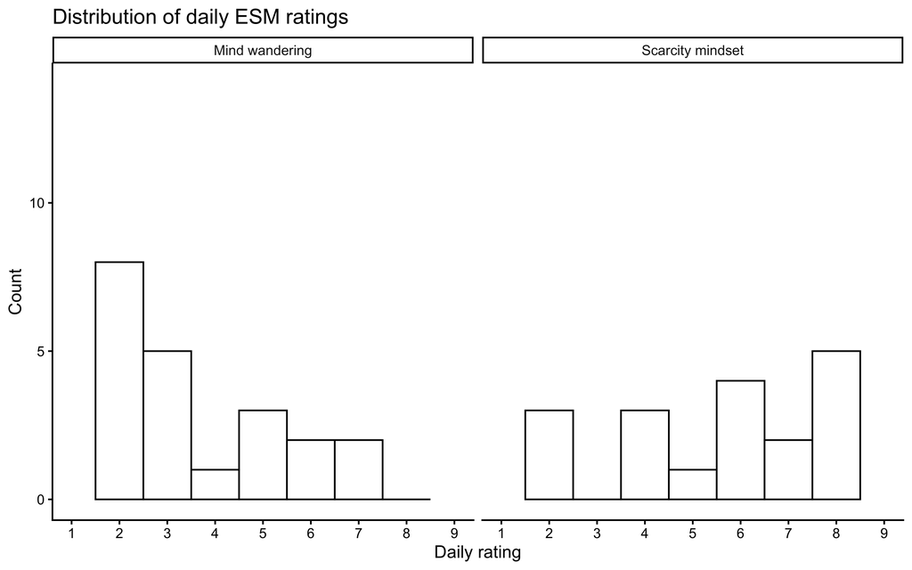

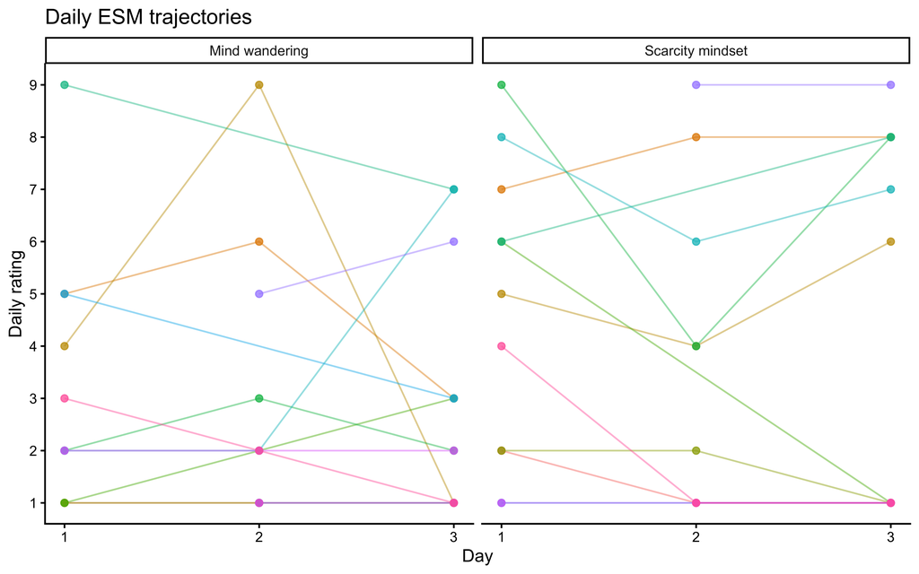

# Person-level summaries

This section treats each participant’s set of daily responses as a small time series and extracts person-level features: mean level, variability, entropy, mean square of successive differences, and probability of acute change. These metrics are useful for describing how participants differ in their average experiences and in the stability of those experiences across days.

```r
person_metrics <- datal %>%
  dplyr::group_by(id) %>%
  dplyr::summarise(
    mean_mind = mean(mind, na.rm = TRUE),
    sd_mind = sd(mind, na.rm = TRUE),
    entropy_mind = safe_entropy(mind),
    mssd_mind = my_mssd(mind),
    pac_mind = my_pac(mind, threshold = .30),
    count_mind = sum(!is.na(mind)),
    mean_scar = mean(scar, na.rm = TRUE),
    sd_scar = sd(scar, na.rm = TRUE),
    entropy_scar = safe_entropy(scar),
    mssd_scar = my_mssd(scar),
    pac_scar = my_pac(scar, threshold = .30),
    count_scar = sum(!is.na(scar)),
    .groups = "drop"
  )
```

Person-level ESM metrics

| ID | Mean mind wandering | SD mind wandering | Entropy mind wandering | MSSD mind wandering | PAC mind wandering | Mind observations | Mean scarcity | SD scarcity | Entropy scarcity | MSSD scarcity | PAC scarcity | Scarcity observations |
| --- | --- | --- | --- | --- | --- | --- | --- | --- | --- | --- | --- | --- |
| 1 | 1.00 | 0.00 | -0.00 | 0.00 | 0.00 | 2.00 | 1.50 | 0.71 | 0.69 | 1.00 | 0.00 | 2.00 |
| 2 | 4.67 | 1.53 | 1.10 | 5.00 | 0.50 | 3.00 | 7.67 | 0.58 | 0.64 | 0.50 | 0.50 | 3.00 |
| 3 | 4.67 | 4.04 | 1.10 | 44.50 | 0.50 | 3.00 | 5.00 | 1.00 | 1.10 | 2.50 | 0.50 | 3.00 |
| 4 | 1.00 | 0.00 | -0.00 | 0.00 | 0.00 | 3.00 | 1.67 | 0.58 | 0.64 | 0.50 | 0.00 | 3.00 |
| 5 | 2.00 | 1.41 | 0.69 | 4.00 | 1.00 | 2.00 | 3.50 | 3.54 | 0.69 | 25.00 | 0.00 | 2.00 |
| 6 | 2.33 | 0.58 | 0.64 | 1.00 | 0.50 | 3.00 | 7.00 | 2.65 | 1.10 | 20.50 | 0.50 | 3.00 |
| 7 | 8.00 | 1.41 | 0.69 | 4.00 | 0.00 | 2.00 | 7.00 | 1.41 | 0.69 | 4.00 | 1.00 | 2.00 |
| 8 | 3.67 | 2.89 | 0.64 | 12.50 | 0.50 | 3.00 | 7.00 | 1.00 | 1.10 | 2.50 | 0.50 | 3.00 |
| 9 | 4.00 | 1.41 | 0.69 | 4.00 | 0.00 | 2.00 | 1.00 | 0.00 | -0.00 | 0.00 | 0.00 | 2.00 |
| 10 | 1.00 | 0.00 | -0.00 | 0.00 | 0.00 | 2.00 | 1.00 | 0.00 | -0.00 | 0.00 | 0.00 | 2.00 |
| 11 | 5.50 | 0.71 | 0.69 | 1.00 | 1.00 | 2.00 | 9.00 | 0.00 | -0.00 | 0.00 | 0.00 | 2.00 |
| 12 | 2.00 | 0.00 | -0.00 | 0.00 | 0.00 | 3.00 | 1.00 | 0.00 | -0.00 | 0.00 | 0.00 | 3.00 |
| 13 | 1.00 | 0.00 | -0.00 | 0.00 | 0.00 | 2.00 | 1.00 | 0.00 | -0.00 | 0.00 | 0.00 | 2.00 |
| 14 | 2.00 | 1.00 | 1.10 | 1.00 | 0.00 | 3.00 | 2.00 | 1.73 | 0.64 | 4.50 | 0.00 | 3.00 |

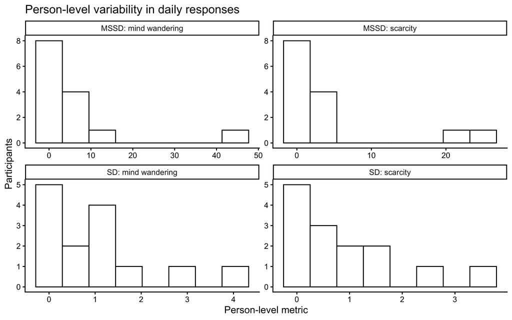

# Within-person covariability

The next analysis examines whether mind wandering and scarcity covary within individuals. Because each person has at most three observations, the person-specific correlations and slopes are unstable. They are included here as descriptive feature extraction rather than as strong individual-difference estimates.

```r
within_person_assoc <- datal %>%
  dplyr::group_by(id) %>%
  dplyr::summarise(
    n_pairwise = sum(stats::complete.cases(mind, scar)),
    corr_mind_scar = safe_cor(mind, scar),
    cov_mind_scar = safe_cov(mind, scar),
    slope_scar_from_mind = ifelse(
      n_pairwise >= 2 && sd(mind, na.rm = TRUE) > 0,
      coef(lm(scar ~ mind))[2],
      NA_real_
    ),
    .groups = "drop"
  ) %>%
  dplyr::mutate(
    fisher_z_corr = psych::fisherz(corr_mind_scar),
    fisher_z_corr = ifelse(is.infinite(fisher_z_corr), NA_real_, fisher_z_corr)
  )
```

Within-person association between mind wandering and scarcity

| ID | Pairwise observations | Within-person correlation | Within-person covariance | Individual slope: scarcity from mind wandering | Fisher z correlation |
| --- | --- | --- | --- | --- | --- |
| 1 | 2.00 |  | 0.00 |  |  |
| 2 | 3.00 | -0.19 | -0.17 | -0.07 | -0.19 |
| 3 | 3.00 | -0.99 | -4.00 | -0.24 | -2.63 |
| 4 | 3.00 |  | 0.00 |  |  |
| 5 | 2.00 | -1.00 | -5.00 | -2.50 | -18.37 |
| 6 | 3.00 | -0.98 | -1.50 | -4.50 | -2.35 |
| 7 | 2.00 | -1.00 | -2.00 | -1.00 | -18.37 |
| 8 | 3.00 | 0.00 | 0.00 | 0.00 | 0.00 |
| 9 | 2.00 |  | 0.00 | -0.00 |  |
| 10 | 2.00 |  | 0.00 |  |  |
| 11 | 2.00 |  | 0.00 | 0.00 |  |
| 12 | 3.00 |  | 0.00 |  |  |
| 13 | 2.00 |  | 0.00 |  |  |
| 14 | 3.00 | 0.87 | 1.50 | 1.50 | 1.32 |

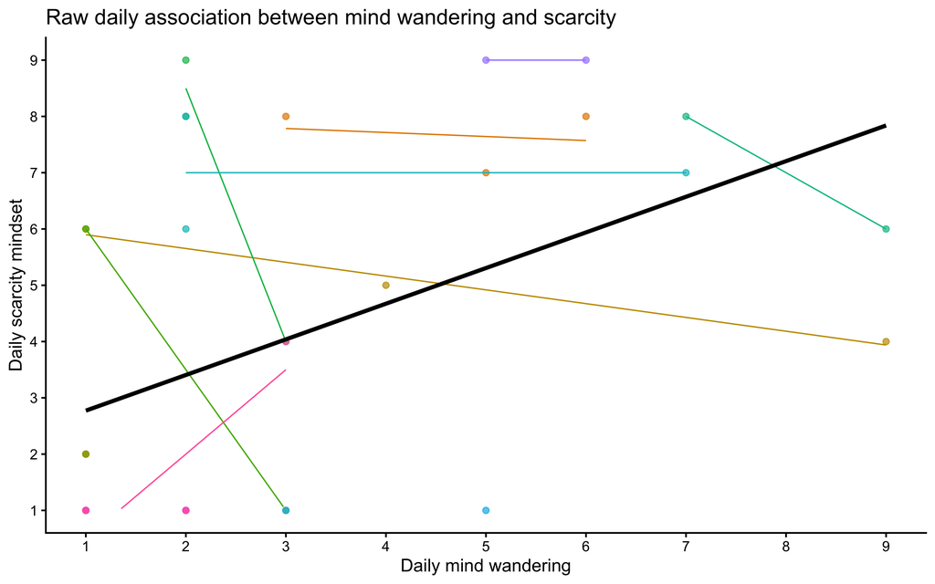

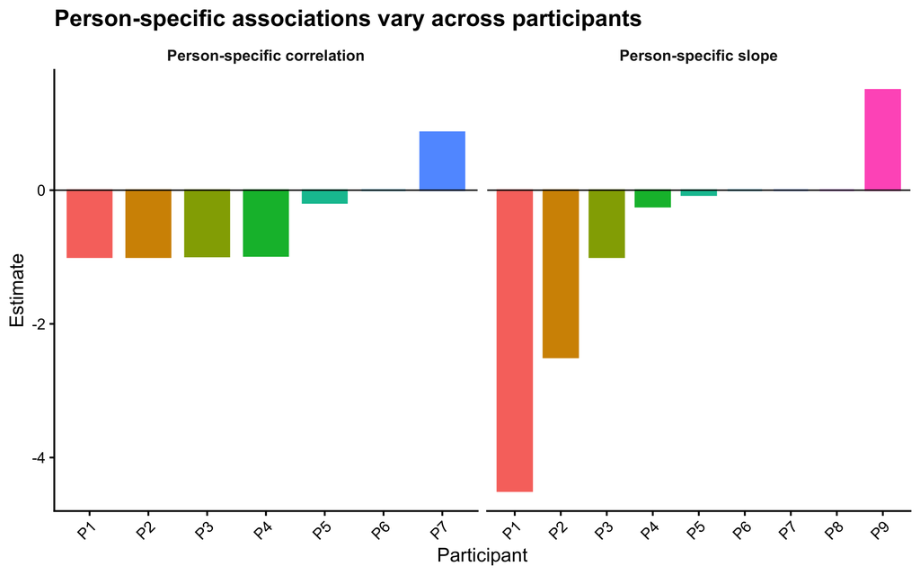

# Multilevel decomposition of scarcity and mind wandering

The multilevel model separates scarcity into two components:

- **Between-person scarcity:** whether a participant tends to report higher scarcity than other participants.
- **Within-person scarcity:** whether a participant reports more scarcity than usual on a given day.

This helps distinguish whether mind wandering is associated with stable between-person differences in scarcity or with day-to-day deviations from a participant’s own average scarcity.

```r
person_means <- datal %>%
  dplyr::group_by(id) %>%
  dplyr::summarise(
    mean_mind = mean(mind, na.rm = TRUE),
    mean_scar = mean(scar, na.rm = TRUE),
    .groups = "drop"
  ) %>%
  dplyr::mutate(
    mean_mind_c = as.numeric(scale(mean_mind, center = TRUE, scale = FALSE)),
    mean_scar_c = as.numeric(scale(mean_scar, center = TRUE, scale = FALSE))
  )

model_data <- datal %>%
  dplyr::left_join(person_means, by = "id") %>%
  dplyr::mutate(
    mind_state = mind - mean_mind,
    scar_state = scar - mean_scar
  )
```

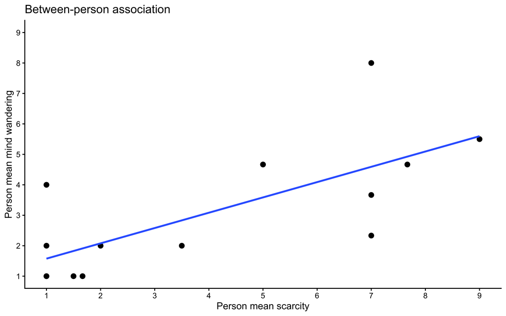

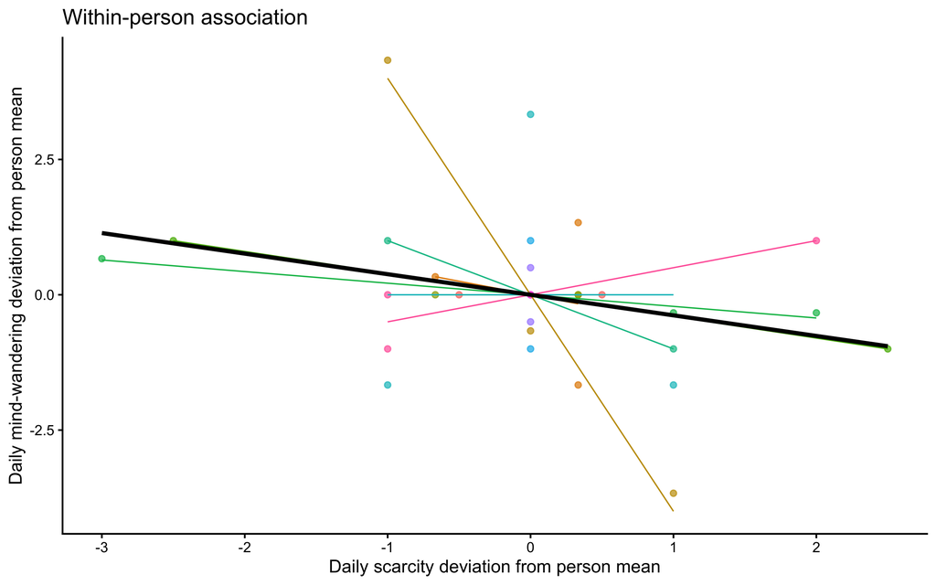

```r
# Unconditional models estimate how much variance is between versus within participants.
umm_mind <- nlme::lme(
  fixed = mind ~ 1,
  random = ~ 1 | id,
  data = model_data,
  na.action = na.exclude,
  control = nlme::lmeControl(opt = "optim")
)

umm_scar <- nlme::lme(
  fixed = scar ~ 1,
  random = ~ 1 | id,
  data = model_data,
  na.action = na.exclude,
  control = nlme::lmeControl(opt = "optim")
)

# State-trait model: mind wandering predicted by within-person and between-person scarcity.
state_trait_model <- nlme::lme(
  fixed = mind ~ scar_state + mean_scar_c,
  random = ~ 1 | id,
  data = model_data,
  na.action = na.exclude,
  control = nlme::lmeControl(opt = "optim")
)
```

Intraclass correlations from unconditional models

| Outcome | Between-person variance | Within-person variance | ICC |
| --- | --- | --- | --- |
| Mind wandering | 2.88 | 3.07 | 0.48 |
| Scarcity mindset | 8.27 | 1.92 | 0.81 |

Multilevel model predicting daily mind wandering

| Predictor | b | SE | df | t | p |
| --- | --- | --- | --- | --- | --- |
| Intercept | 3.01 | 0.39 | 20 | 7.75 | < .001 |
| Within-person scarcity | -0.38 | 0.27 | 20 | -1.41 | 0.174 |
| Between-person scarcity | 0.49 | 0.13 | 12 | 3.61 | 0.004 |

In this model, **within-person scarcity** estimates whether participants reported more mind wandering on days when they felt more scarcity than usual. **Between-person scarcity** estimates whether participants who generally felt more scarcity also generally reported more mind wandering.

# Export portfolio figures

The plot objects below are named consistently with the files they export. Set `eval=TRUE` when you are ready to write the images to your website folder.

```r
fig_dir <- "../assets/img"

if (!dir.exists(fig_dir)) {
  dir.create(fig_dir, recursive = TRUE)
}

# Figure 1: Distribution of daily ratings across all person-days.
ggsave(
  filename = file.path(fig_dir, "esm-distribution-plot.png"),
  plot = esm_distribution_plot,
  width = 8,
  height = 4.8,
  dpi = 300
)

# Figure 2: Daily/person trajectories over time.
ggsave(
  filename = file.path(fig_dir, "esm-daily-trajectories.png"),
  plot = esm_daily_trajectories,
  width = 10,
  height = 4.8,
  dpi = 300
)

# Figure 3: Person-level variability metrics.
ggsave(
  filename = file.path(fig_dir, "esm-within-person-variability.png"),
  plot = esm_variability_plot,
  width = 8,
  height = 5.8,
  dpi = 300
)

# Figure 4: Raw daily mind wandering/scarcity association.
ggsave(
  filename = file.path(fig_dir, "esm-raw-mind-scarcity-association.png"),
  plot = esm_raw_mind_scarcity_association,
  width = 8,
  height = 5.5,
  dpi = 300
)

# Figure 5: Between-person association using person means.
ggsave(
  filename = file.path(fig_dir, "esm-between-person-association.png"),
  plot = esm_between_person_association,
  width = 7,
  height = 5.2,
  dpi = 300
)

# Figure 6: Person-centered within-person association.
ggsave(
  filename = file.path(fig_dir, "esm-within-person-association.png"),
  plot = esm_within_person_association,
  width = 8,
  height = 5.5,
  dpi = 300
)

# Optional Figure 7: Heterogeneity in person-specific slopes/correlations.
# This chunk will only work if you keep `esm_slope_heterogeneity_plot` in the report.
ggsave(
  filename = file.path(fig_dir, "esm-slope-heterogeneity.png"),
  plot = esm_slope_heterogeneity_plot,
  width = 8,
  height = 5,
  dpi = 300
)
```

# Brief takeaway

This pilot demonstrates an ESM workflow for moving from raw repeated daily observations to interpretable within-person summaries. The clearest portfolio-relevant outputs are the daily trajectory plot, the variability plot, the raw and person-centered association plots, and the multilevel model that separates within-person and between-person associations between scarcity and mind wandering.